# HW2

Uran Maimekov

2024-06-03

All work was done in Amarel cluster except `multiqc`. I downloaded **ogdens_data** tarball into my folder on the cluster. Unzip tarball, using `tar -xvf ogdens_data.tar`

### Question 1.

**Use cat in Unix to merge the proband_29.fq.gz and the proband_short.fg.gz files – these are from the same sample**

```r
cat fastq/proband_29.fq.qz fastq/proband_short.fq.qz > fastq/proband_merged.fq.qz
```

### Question 2.

**Use FASTQC and MultiQC to summarize the fastq files for these datasets. For which diagnostics do these data fail? Should we be concerned about the quality of these data? Why or why not?**

Convert **fastq** files to **fastqc** files using

```r
fastqc fastq/*.fq.gz --outdir=fastqc/
```

Do **MultiQC** on the samples (installed and run on local machine), obtain **fastqc/multiqc_report.html** file.

### Question 3.

**Align genome sequences from these human sequencing experiment using bwa to the chrX_5MB.fa reference.**

1. Index genome

```r
bwa index genome/chrX_5MB.fa
```

2. Align fastq files to a reference genome.

```r
bwa mem genome/chrX_5MB.fa fastq/sample.fq.gz > bwa_mem_align/sample.sam
```

3. Convert SAM to BAM

```r
samtools view -bS bwa_mem_align/sample.sam > bam/sample.bam
```

### Question 4.

**Process the reads through samtools mpileup to generate a .vcf file.**

Repeat for each sample

1. Sort bam file

```r
samtools sort bwa_aligned_reads/sample.bam -o bwa_aligned_reads/sample.sorted.bam
```

2. Index the BAM file:

```r
samtools index bwa_aligned_reads/sample.sorted.bam
```

2. Multiple sample SNP calling:

```r
samtools mpileup -f genome/chrX_5MB.fa bwa_aligned_reads/sample.sorted.bam > mpile_vcf/sample.vcf
```

### Question 5.

**Complete this process using gatk to generate an alternative .vcf file. How do the .vcf files compare?**

GATK program is not available on Amarel and has java error incompatibility. To solve this issue I downloaded **gatk** tarball into my folder on Amarel cluster and load java/17.0.6 version to resolve error.

```r
module load java/17.0.6
```

Then run the script using `bash`

```r
#!/bin/bash

module load samtools
module load bwa
module load FastQC
module load java/17.0.6

mkdir genome
mkdir bwa_aligned_reads
mkdir vcf

# Path to the reference genome
ref_genome="genome/chrX_5MB.fa"

# Index the genome
bwa index $ref_genome

# Index reference
samtools faidx $ref_genome

# Make sequence dictionary
gatk CreateSequenceDictionary -R $ref_genome

samples=("brother_short" "mother_short" "grandmother_short" "proband_short" "proband_29" "uncle_short")

# Align read adding read groups for appropriate usage for gatk
for sample in "${samples[@]}"
do
    # Align reads with BWA MEM, specifying read group information
    bwa mem -t 4 -R "@RG\tID:${sample}\tPL:ILLUMINA\tSM:${sample}" $ref_genome "fastq/${sample}.fq.qz" > "bwa_aligned_reads/${sample}.sam"

    # Convert SAM to BAM
    samtools view -bS "bwa_aligned_reads/${sample}.sam" > "bwa_aligned_reads/${sample}.bam"

    # Sort BAM file
    samtools sort "bwa_aligned_reads/${sample}.bam" -o "bwa_aligned_reads/${sample}.sorted.bam"

    # Index sorted BAM file
    samtools index "bwa_aligned_reads/${sample}.sorted.bam"

    # Call variants using GATK HaplotypeCaller
    gatk-4.5.0.0/gatk HaplotypeCaller -R $ref_genome -I "bwa_aligned_reads/${sample}.sorted.bam" -O "vcf/${sample}.vcf"
done
```

### Question 6.

**Generate a Manhattan plot, comparing the proband sequences with the sequences from the brother and uncle. List the SNPs/regions of interest.**

```r
library(vcfR)
library(ggplot2)
library(qqman)
library(dplyr)
library(DT)
```

```r
process_vcf <- function(file_path) {
  # Read VCF file
  vcf <- read.vcfR(file_path)

  # Extract genotype data (if needed)
  geno <- extract.gt(vcf)

  # Create a data frame with the necessary columns
  vcf_data <- as.data.frame(vcf@fix)
  vcf_data <- vcf_data[, c('CHROM', 'POS', 'REF', 'ALT', 'QUAL')]

  # Convert columns to appropriate types
  vcf_data$POS <- as.numeric(vcf_data$POS)
  vcf_data$QUAL <- as.numeric(as.character(vcf_data$QUAL))
  vcf_data$logp <- vcf_data$QUAL / 10

  return(vcf_data)
}

# Process the VCF files
vcf_data_proband_29 <- process_vcf("proband_short.vcf")
vcf_data_proband_short <- process_vcf("proband_29.vcf")
vcf_data_brother <- process_vcf("brother_short.vcf")
vcf_data_uncle <- process_vcf("uncle_short.vcf")
vcf_data_mother <- process_vcf("mother_short.vcf")
vcf_data_grandmother <- process_vcf("grandmother_short.vcf")

vcf_data_proband_short$SAMPLE <- "Proband_short"
vcf_data_proband_29$SAMPLE <- "Proband_29"
vcf_data_brother$SAMPLE <- "Brother"
vcf_data_uncle$SAMPLE <- "Uncle"
vcf_data_mother$SAMPLE <- "Mother"
vcf_data_grandmother$SAMPLE <- "Grandmother"
```

**Manhattan plot of proband, brother and uncle**

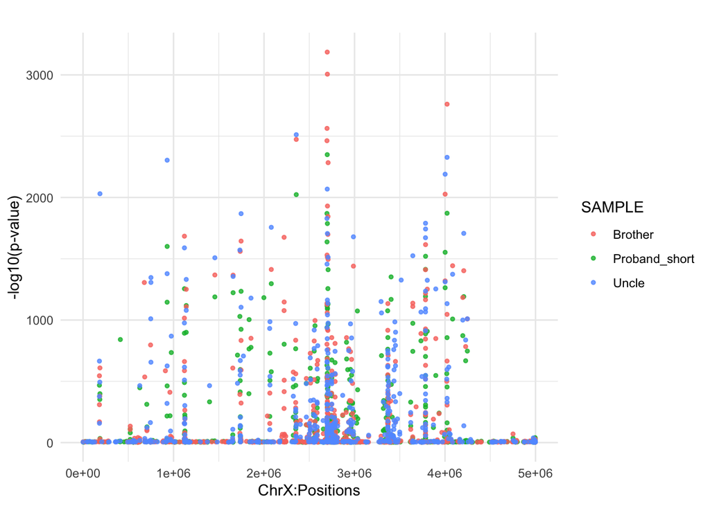

```r
vcf_data <- bind_rows(vcf_data_proband_short, vcf_data_brother, vcf_data_uncle)
ggplot(vcf_data, aes(x = POS, y = logp, color = SAMPLE)) +
  geom_point(alpha = 0.8, size = 1) +
  theme_minimal() +
  labs(title = "", x = "ChrX:Positions", y = "-log10(p-value)") +
  theme_minimal()
```

**Here is the table of SNPs across brother and uncle sequences.**

```r
vcf_data_brother_uncle <- bind_rows(vcf_data_brother, vcf_data_uncle)

result <- vcf_data_brother_uncle %>% group_by(POS) %>% summarise(sample_count = n_distinct(SAMPLE)) %>% filter(sample_count == 2) %>% pull(POS)

result <- vcf_data_brother_uncle %>%
  filter(POS %in% result) %>% arrange(POS)

brother_uncle_snp_pos <- unique(result[['POS']])

datatable(result, options = list(pageLength=6))
```

|  | CHROM | POS | REF | ALT | QUAL | logp | SAMPLE |
| --- | --- | --- | --- | --- | --- | --- | --- |
| 1 | chrX_149913753 | 180971 | T | C | 3093.06 | 309.306 | Brother |
| 2 | chrX_149913753 | 180971 | T | C | 3768.06 | 376.806 | Uncle |
| 3 | chrX_149913753 | 181052 | T | C | 5451.06 | 545.106 | Brother |
| 4 | chrX_149913753 | 181052 | T | C | 6649.06 | 664.9060000000001 | Uncle |
| 5 | chrX_149913753 | 181338 | A | C | 1692.06 | 169.206 | Brother |
| 6 | chrX_149913753 | 181338 | A | C | 1575.06 | 157.506 | Uncle |
| 7 | chrX_149913753 | 185132 | C | T | 3790.06 | 379.006 | Brother |
| 8 | chrX_149913753 | 185132 | C | T | 4934.06 | 493.4060000000001 | Uncle |
| 9 | chrX_149913753 | 706169 | A | G | 972.06 | 97.20599999999999 | Brother |
| 10 | chrX_149913753 | 706169 | A | G | 1227.06 | 122.706 | Uncle |

[output cut: 498 more lines]

**Here is the table of SNPs across proband, brother and uncle sequences.**

```r
vcf_data <- bind_rows(vcf_data_proband_short, vcf_data_brother, vcf_data_uncle)

result_2 <- vcf_data %>% group_by(POS) %>% summarise(sample_count = n_distinct(SAMPLE)) %>% filter(sample_count == 3) %>% pull(POS)

result_2 <- vcf_data %>%
  filter(POS %in% result_2) %>% arrange(POS)

proband_brother_uncle_snp_pos <- unique(result_2[['POS']])

datatable(result_2, options = list(pageLength=6))
```

|  | CHROM | POS | REF | ALT | QUAL | logp | SAMPLE |
| --- | --- | --- | --- | --- | --- | --- | --- |
| 1 | chrX_149913753 | 180971 | T | C | 4680.06 | 468.006 | Proband_short |
| 2 | chrX_149913753 | 180971 | T | C | 3093.06 | 309.306 | Brother |
| 3 | chrX_149913753 | 180971 | T | C | 3768.06 | 376.806 | Uncle |
| 4 | chrX_149913753 | 185132 | C | T | 3521.06 | 352.106 | Proband_short |
| 5 | chrX_149913753 | 185132 | C | T | 3790.06 | 379.006 | Brother |
| 6 | chrX_149913753 | 185132 | C | T | 4934.06 | 493.4060000000001 | Uncle |
| 7 | chrX_149913753 | 706169 | A | G | 1284.06 | 128.406 | Proband_short |
| 8 | chrX_149913753 | 706169 | A | G | 972.06 | 97.20599999999999 | Brother |
| 9 | chrX_149913753 | 706169 | A | G | 1227.06 | 122.706 | Uncle |
| 10 | chrX_149913753 | 1119494 | T | A | 301.06 | 30.106 | Proband_short |

[output cut: 596 more lines]

**We are trying to find SNP positions where brother and uncle have same SNP, but proband has another SNP or does not have at all. For this I took SNP positions common for brother and uncle and common for proband, brother and uncle. And found out differect SNP positions between them**

```r
diff_snp_pos <- setdiff(brother_uncle_snp_pos, proband_brother_uncle_snp_pos)
diff_snp_pos
```

```
##  [1]  181052  181338  966905  968242 1124343 1654910 2400637 2401671 2499972
## [10] 2512198 2513055 2513471 2513863 2553813 2565440 2566885 2586741 2698840
## [19] 2699443 2702652 2708717 2711449 2748545 2788097 2934833 2935497 2935785
## [28] 2935869 2939460 2957805 2962275 2987688 3155977 3369695 3369733 3372799
## [37] 3372973 3373393 3376298 3376745 3389253 3396523 3399481 3784237 4282367
## [46] 4525946 4975409 4984456 4990952 4991424 4991950 4995413
```

### Question 7.

**Are the mother and grandmother heterozygous at these positions? Please show your work. Why is this important.**

I took SNP positions found above and analyze mother and grandmother sequences.

```r
mother_grandmother <- rbind(subset(vcf_data_mother, POS %in% c(diff_snp_pos)), subset(vcf_data_grandmother, POS %in% c(diff_snp_pos)))
df <- mother_grandmother


result_3 <- df %>% group_by(POS) %>% summarise(sample_count = n_distinct(SAMPLE)) %>% filter(sample_count == 2) %>% pull(POS)

result_3 <- df %>%
  filter(POS %in% result_3) %>% arrange(POS)

datatable(subset(result_3, POS %in% c(diff_snp_pos)), options = list(pageLength=6))
```

|  | CHROM | POS | REF | ALT | QUAL | logp | SAMPLE |
| --- | --- | --- | --- | --- | --- | --- | --- |
| 12 | chrX_149913753 | 181052 | T | C | 3500.64 | 350.064 | Mother |
| 15 | chrX_149913753 | 181052 | T | C | 2655.64 | 265.564 | Grandmother |
| 13 | chrX_149913753 | 181338 | A | C | 400.64 | 40.064 | Mother |
| 16 | chrX_149913753 | 181338 | A | C | 293.64 | 29.364 | Grandmother |
| 94 | chrX_149913753 | 966905 | T | C | 156.64 | 15.664 | Mother |
| 951 | chrX_149913753 | 966905 | T | C | 176.64 | 17.664 | Grandmother |
| 116 | chrX_149913753 | 1124343 | A | G | 66.32 | 6.632 | Mother |
| 112 | chrX_149913753 | 1124343 | A | G | 102.84 | 10.284 | Grandmother |
| 242 | chrX_149913753 | 2400637 | A | C | 673.64 | 67.364 | Mother |
| 227 | chrX_149913753 | 2400637 | A | C | 320.64 | 32.064 | Grandmother |

[output cut: 56 more lines]